# Phyloacc

### 3.2.5 GO similarity clustering

Next we will do a GO term clustering to figure out common groups of GO terms

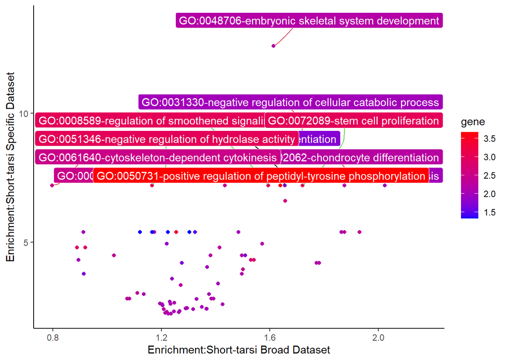

```r
#R
library(stringr)
#do GO similarity clustering for each group
panther_out <- fread("all_enrich_m2.txt", sep = "\t", header = T)
panther_cat1_out <- fread("cat1_enrich_m2.txt", sep = "\t", header = T)
panther_merge <- merge(panther_out, panther_cat1_out, by = "term.id", all.y=T, all.x=F)
panther_merge$enrich_diff <- (panther_merge$enrich.y - panther_merge$enrich.x)
panther_merge <- subset(panther_merge, (number_in_reference.y >= 5) & (median.y >= 1) & (pgo.y < 0.05))

library(jsonlite)
sub_json <- read_json("panther_results_cat1.json")

go_output <- data.frame(gene=character(), GO=character())
for (i in seq(1,length(sub_json$overrepresentation$group))){
  if (is.null(names(sub_json$overrepresentation$group[[i]]$result))){
    for (j in seq(1, length(sub_json$overrepresentation$group[[i]]$result))){
      if (sub_json$overrepresentation$group[[i]]$result[[j]]$input_list$number_in_list > 0){
        go_output <- rbind(go_output, data.frame(gene = unlist(sub_json$overrepresentation$group[[i]]$result[[j]]$input_list$mapped_id_list$mapped_id),
                                                 GO = sub_json$overrepresentation$group[[i]]$result[[j]]$term$id))
      }
    }
  }
  else{
    if (sub_json$overrepresentation$group[[i]]$result$input_list$number_in_list > 0){
      if (is.null(sub_json$overrepresentation$group[[i]]$result$term$id)){
        go_output <- rbind(go_output,
                           data.frame(gene = unlist(sub_json$overrepresentation$group[[i]]$result$input_list$mapped_id_list$mapped_id),
                                                   GO = NA))
      }
      else{
        go_output <- rbind(go_output,
                           data.frame(gene = unlist(sub_json$overrepresentation$group[[i]]$result$input_list$mapped_id_list$mapped_id),
                                                   GO = sub_json$overrepresentation$group[[i]]$result$term$id))
      }
    }
  }
}

#calculate per gene score for each GO
gene_taxa <- read.table("gene_taxa_m2.txt", sep = "\t", header = T)
gene_taxa_cat1 <- read.table("gene_taxa_cat1_m2.txt", sep = "\t", header = T)
go_scores <- data.frame(GO=panther_merge$term.id, gene=NA, element=NA)
for (GO_term in panther_merge$term.id){
  go_scores$gene[which(go_scores$GO %in% GO_term)] <- (mean(gene_taxa$targets_with_shifts[gene_taxa$gene %in% go_output$gene[go_output$GO %in% GO_term]]))
}

panther_merge <- merge(panther_merge, go_scores, by.x="term.id", by.y="GO")
panther_merge_max <- panther_merge[which(panther_merge$enrich_diff > 5),]
panther_merge_max$label <- paste(panther_merge_max$term.id, panther_merge_max$term.label.x, sep = "-")

library(ggrepel)

ggplot(panther_merge, aes(x=enrich.x, y=enrich.y, color=gene, fill=gene, segment.color=gene))+
  geom_point()+
  scale_color_gradient(low = "blue", high = "red") +
  xlab("Enrichment:Short-tarsi Broad Dataset") +
  ylab("Enrichment:Short-tarsi Specific Dataset") +
  geom_label_repel(data = panther_merge_max, aes(x=enrich.x, y=enrich.y, label=label),
                  color = "white",
                  nudge_x = .15,
                  box.padding = 0.1,
                  nudge_y = 1,
                  segment.curvature = -0.1,
                  segment.ncp = 3,
                  segment.angle = 20)+
  scale_fill_gradient(low = "blue", high = "red")+
  theme_classic()
```

Plot heat maps of GO similarity

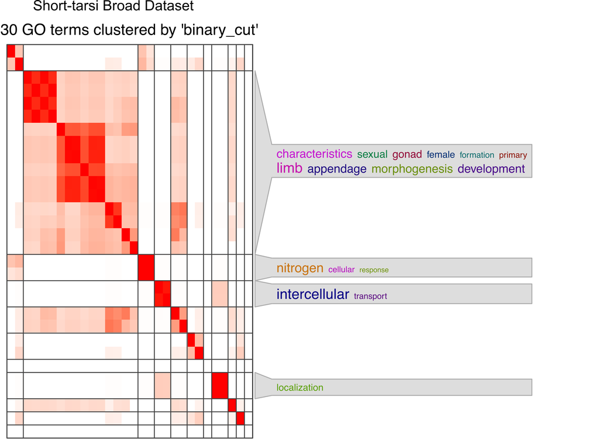

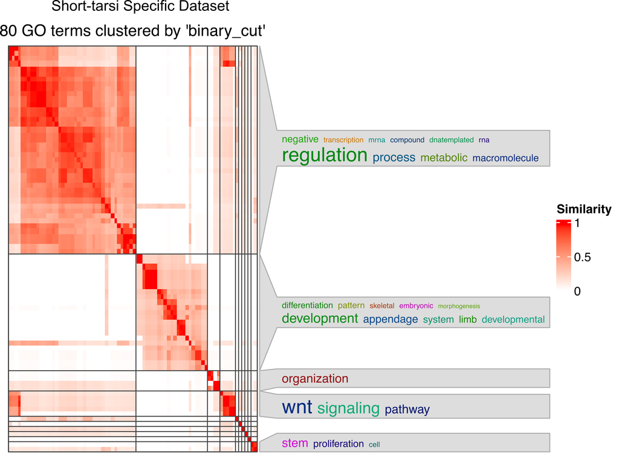

```r
library(simplifyEnrichment)
pdf("go_sub_heatmap_m2.pdf", height = 5, width = 7)
mat_all <- GO_similarity(all_sigs$term.id, ont = "BP", db = 'org.Gg.eg.db')
go_df <- simplifyGO(mat_all)
dev.off()

pdf("go_cat1_heatmap_m2.pdf", height = 5, width = 7)
mat_cat1 <- GO_similarity(cat1_sigs$term.id, ont = "BP", db = 'org.Gg.eg.db')
go_df_cat1 <- simplifyGO(mat_cat1)
dev.off()
```

## 3.3 Motif search

We looked for motifs potentially associated with limb development. To do this we first generated a list of CEs that were closest to known limb development genes.

```r
limb_genes <- c("GLI3R", "TBX2", "SMAD2", "BMP4",
                "GREM1", "GLIA", "SHH", "GDF11",
                "HOXA9", "HOXA10", "HOXA11", "HOXA12", "HOXA13",
                "HOXB9", "HOXB10", "HOXB11", "HOXB12", "HOXB13",
                "HOXC9", "HOXC10", "HOXC11", "HOXC12", "HOXC13",
                "HOXD9", "HOXD10", "HOXD11", "HOXD12", "HOXD13",
                "TBX4", "PITX1", "FGF10", "PIZF", "HOXB5",
                "IRX3", "IRX5", "GLI3", "SALL4", "PBX1",
                "PBX2", "HAND2", "TBX3", "TBX18", "GSC",
                "ISL1", "ETS1", "ETS2", "LMX1B", "WNT7A",
                "EN1", "SP6", "SP8", "P63", "DIX5",
                "DIX6", "FGF8", "FGF4", "FGF7", "FGF9",
                "FGF17", "GREM1", "MEIS1", "MEIS2",
                "CYB26B1", "TBX5", "VEGF", "MMP9", "CBFA1",
                "OSX", "IHH", "PTHRP", "CNP", "FOS",
                "SOX5", "SOX6", "SOX9", "FGFR3", "GDF5")
limb_genes_ce <- subset(closest, gene %in% limb_genes)

macro <- c("NC_052532.1", "NC_052533.1", "NC_052534.1", "NC_052535.1","NC_052536.1",
           "NC_052537.1", "NC_052538.1", "NC_052539.1", "NC_052542.1")
micro <- c("NC_052544.1", "NC_052546.1", "NC_052548.1", "NC_052550.1", "NC_052555.1", "NC_052558.1","NC_052565.1")
Z <- "NC_052572.1"

limb_genes_ce$file <- paste(limb_genes_ce$V1, "/", limb_genes_ce$V4, ".fa", sep = "")
limb_genes_ce[which(limb_genes_ce$V1 %in% macro), "file"] <- paste("fasta_macro", unname(unlist(limb_genes_ce[which(limb_genes_ce$V1 %in% macro), "file"])), sep = "/")
limb_genes_ce[which(limb_genes_ce$V1 %in% micro), "file"] <- paste("fasta_micro", unname(unlist(limb_genes_ce[which(limb_genes_ce$V1 %in% micro), "file"])), sep = "/")
limb_genes_ce[which(limb_genes_ce$V1 %in% Z), "file"] <- gsub("NC_052572.1", "fasta_Z", unname(unlist(limb_genes_ce[which(limb_genes_ce$V1 %in% Z), "file"])))

write.table(limb_genes_ce$file, "limb_ces_m2.txt", quote = F, row.names = F, col.names = F)
```

Next we compiled list of motifs for these genes from [JASPAR](https://jaspar.genereg.net/#). We used the vertebrates CORE non-redundant motif file. We used MEME to search for motifs.

```bash
#bash
while IFS= read -r line; do
        fbname=$(basename "$line" .fa)
        echo $fbname
        sed 's/-//g' ${line} > fastas/${fbname}.fa
        ~/meme/bin/mast limb.meme fastas/${fbname}.fa -oc $fbname -sep
done < "limb_ces_m2.txt"
```

To analyze MEME output and then correlate acceleration to gain of motif

```r
#read memes compiled from JASPAR
read_memes <- read.table("limb_motifs.txt", header = T)
limb_genes_motifs <- as.data.frame(limb_genes_ce[,c("V4", "V1", "V2", "V3", "V14", "gene")])
colnames(limb_genes_motifs) <- c("ce_id", "scaffold", "start", "end", "length", "gene")
limb_genes_motifs[,read_memes$ALT_ID] <- "NA"

for (x in limb_genes_motifs$ce_id) {
  tryCatch(
    {
      meme_hit <- read.table(paste("./meme/", x, "_hits.txt", sep = ""))
    },
    error=function(e) {
      return(data.frame(V1=x, V4=NA))
    }
  )
  unique_memes <- unique(meme_hit$V4)
  for (unique_meme in unique_memes){
    species <- paste(meme_hit$V1[which(meme_hit$V4 %in% unique_meme)], collapse = ",")
    limb_genes_motifs[which(limb_genes_motifs$ce_id %in% x),unique_meme] <- species
  }
}

#get accl species
limb_genes_accl <- subset(phyloacc_subset, phyloacc_subset$original.id %in% limb_genes_motifs$ce_id)
rate_data_M2 <- fread("M2_elem_Z.txt", header = T)
rate_data_M2 <- subset(rate_data_M2, rate_data_M2$`Locus ID` %in% limb_genes_accl$phyloacc.id)
rate_data <- rate_data_M2[,1:80]

results_m2 <- fread("rate_postZ_M2.txt", header = T, sep = "\t")
results_m2 <- subset(results_m2, results_m2$`Locus ID` %in% limb_genes_accl$phyloacc.id)
results <- results_m2[,c(1:6,seq(10,322,4))]
colnames(results) <- gsub("_3", "", colnames(results))

for (x in limb_genes_accl$phyloacc.id){
  limb_genes_accl[which(limb_genes_accl$phyloacc.id %in% x),"accl_taxa"] <-
    paste(intersect(colnames(rate_data)[rate_data[which(rate_data$`Locus ID` %in% x),] == 2],
                  colnames(results)[results[which(results$`Locus ID` %in% x),] >= 0.9]),
          collapse = ",")
}

#calculate intersect
limb_genes_motifs_accl <- merge(limb_genes_motifs, limb_genes_accl, by.x = "ce_id", by.y = "original.id")
limb_genes_motifs_accl[limb_genes_motifs_accl == "NA"] <- ""
targets <- c("Brachypodius_melanocephalos", "Pycnonotus_jocosus",
             "Hirundo_rustica", "Progne_subis", "Riparia_riparia",
             "Chloroceryle_aenea", "Actenoides_hombroni", "Halcyon_senegalensis",
             "Aptenodytes_patagonicus", "Aptenodytes_forsteri", "Pygoscelis_adeliae",
             "Pygoscelis_papua", "Pygoscelis_antarcticus", "Megadyptes_antipodes",
             "Eudyptula_novaehollandiae", "Eudyptula_albosignata", "Eudyptula_minor",
             "Spheniscus_demersus", "Spheniscus_humboldti", "Spheniscus_magellanicus",
             "Eudyptes_pachyrhynchus", "Eudyptes_sclateri", "Eudyptes_chrysolophus",
             "Eudyptes_schlegeli", "Eudyptes_chrysocome", "Eudyptes_filholi",
             "Eudyptes_moseleyi")

for (x in 1:(nrow(limb_genes_motifs_accl))){
  for (y in 7:43){
    limb_genes_motifs_accl[x,y] <- paste(length(unique(strsplit(limb_genes_motifs_accl[x,y], ",")[[1]])),
                                         length(intersect(strsplit(limb_genes_motifs_accl[x,"accl_taxa"], ",")[[1]],
                                                targets)),
                                         length(intersect(strsplit(limb_genes_motifs_accl[x,y], ",")[[1]],
                                                          intersect(strsplit(limb_genes_motifs_accl[x,"accl_taxa"], ",")[[1]],
                                                                    targets))),
                                         length(intersect(strsplit(limb_genes_motifs_accl[x,y], ",")[[1]],
                                                          targets)),
                                         sep=";")
  }
}
colnames(limb_genes_motifs) <- gsub("\\:\\:", "-", colnames(limb_genes_motifs))
interesting <- limb_genes_motifs_accl[,c(1:43,66)]
interesting <- as.data.frame(lapply(interesting, function(y) gsub("^0;[0-9]*;[0-9]*;[0-9]*", "", y)))
interesting <- as.data.frame(lapply(interesting, function(y) gsub("^[0-9]*;[0-9]*;[0-9]*;0", "", y)))
interesting <- as.data.frame(lapply(interesting, function(y) gsub("^[0-9]*;0;0;[0-9]*", "", y)))
#colnames(interesting) <- gsub("\\.\\.", "-", colnames(interesting))
#format: all with motif; accelerated taxa; target accl with motifs; target taxa with motifs

get_accl <- function(motif_data, interesting_data, element, motif){
  accl_taxa <- strsplit(interesting_data[which(interesting_data$ce_id %in% element),"accl_taxa"], ",")[[1]]
  bulbul_accl <- intersect(accl_taxa, c("Brachypodius_melanocephalos", "Pycnonotus_jocosus"))
  king_accl <- intersect(accl_taxa, c("Chloroceryle_aenea", "Actenoides_hombroni", "Halcyon_senegalensis"))
  penguin_accl <- intersect(accl_taxa, c("Aptenodytes_patagonicus", "Aptenodytes_forsteri", "Pygoscelis_adeliae",
                                         "Pygoscelis_papua", "Pygoscelis_antarcticus", "Megadyptes_antipodes",
                                         "Eudyptula_novaehollandiae", "Eudyptula_albosignata", "Eudyptula_minor",
                                         "Spheniscus_demersus", "Spheniscus_humboldti", "Spheniscus_magellanicus",
                                         "Eudyptes_pachyrhynchus", "Eudyptes_sclateri", "Eudyptes_chrysolophus",
                                         "Eudyptes_schlegeli", "Eudyptes_chrysocome", "Eudyptes_filholi",
                                         "Eudyptes_moseleyi"))
  swallow_accl <- intersect(accl_taxa, c("Hirundo_rustica", "Progne_subis", "Riparia_riparia"))
  motif_taxa <- strsplit(motif_data[which(motif_data$ce_id %in% element), motif], ",")[[1]]
  bulbul_motif <- intersect(motif_taxa, c("Brachypodius_melanocephalos", "Pycnonotus_jocosus"))
  king_motif <- intersect(motif_taxa, c("Chloroceryle_aenea", "Actenoides_hombroni", "Halcyon_senegalensis"))
  penguin_motif <- intersect(motif_taxa, c("Aptenodytes_patagonicus", "Aptenodytes_forsteri", "Pygoscelis_adeliae",
                                         "Pygoscelis_papua", "Pygoscelis_antarcticus", "Megadyptes_antipodes",
                                         "Eudyptula_novaehollandiae", "Eudyptula_albosignata", "Eudyptula_minor",
                                         "Spheniscus_demersus", "Spheniscus_humboldti", "Spheniscus_magellanicus",
                                         "Eudyptes_pachyrhynchus", "Eudyptes_sclateri", "Eudyptes_chrysolophus",
                                         "Eudyptes_schlegeli", "Eudyptes_chrysocome", "Eudyptes_filholi",
                                         "Eudyptes_moseleyi"))
  swallow_motif <- intersect(motif_taxa, c("Hirundo_rustica", "Progne_subis", "Riparia_riparia"))
  print(paste("Bulbul accl:", paste(bulbul_accl, collapse = ",")))
  print(paste("Bulbul motif:", paste(bulbul_motif, collapse = ",")))
  print("")
  print(paste("Kingfisher accl:", paste(king_accl, collapse = ",")))
  print(paste("Kingfisher motif:", paste(king_motif, collapse = ",")))
  print("")
  print(paste("Swallow accl:", paste(swallow_accl, collapse = ",")))
  print(paste("Swallow motif:", paste(swallow_motif, collapse = ",")))
  print("")
  print(paste("Penguin accl:", paste(penguin_accl, collapse = ",")))
  print(paste("Penguin motif:", paste(penguin_motif, collapse = ",")))
  print("")
}

#get motifs where there is a potential gain in motif through acceleration
for (x in 7:43){
  for (y in 1:(nrow(interesting))){
    split_vars <- strsplit(interesting[y,x], ";")[[1]]
    if (length(split_vars) == 4){
      if ((split_vars[2] == split_vars[3]) & (split_vars[4] != 27)){
        print(interesting[y, 1])
        print(colnames(interesting)[x])
        get_accl(limb_genes_motifs, limb_genes_motifs_accl, interesting[y, 1], colnames(interesting)[x])
      }
    }
  }
}
```